# Documentação de todas as fontes de ocorrência do Katsuwonus Pelamis (Bonito-Listrado ou Skipjack Tuna)

2024-10-22

IMPORTANTE PARA EXECUTAR DO GITHUB:

1. Definir o diretório de trabalho do RStudio como a pasta “PIBITI” com os arquivos e imagens usadas, em “Files” -> “…” -> Escolher pasta “PIBITI”, e então ir no símbolo de configurações -> “Set as Working Directory”
2. Marcar a opção “Knit” -> “Knit Directory” -> “Current working directory” para mudar o diretório de trabalho a ser usado pelo RMarkdown, para a pasta definida anteriormente
- Mesmo assim, as imagens usadas não aparecerão em “Knit” -> “Knit to HTML”, provavelmente pelo fato que o script está em um diretório diferente das imagens, mesmo que esta mesma função funcione na execução normal do programa.

### Bibliotecas gerais usadas

```r
if(!require(pacman)) {
    install.packages("pacman", dependencies = TRUE);
}
library(pacman)
# Instalando pacotes
p_load(tidyverse, terra, leaflet, viridis)
```

### Variáveis gerais usadas

```r
# paleta de cores do pacote "viridis"
palette_name <- "viridis"
```

Limites de latitude e longitude globais (pois usar os limites de latitude como +90 e -90 irá dar um erro nos rasters, na minha experiência)

```r
lat_min <- -85
lat_max <- 85
long_min <- -180
long_max <- 180

# visualizando limites
leaflet() %>%
  addTiles() %>%  # Adiciona o mapa base
  addRectangles(
    lng1 = long_min, lat1 = lat_min,  # Canto inferior esquerdo
    lng2 = long_max, lat2 = lat_max,  # Canto superior direito
    color = "blue", weight = 2,  # Cor e espessura da borda
    fill = FALSE, popup = "Area Global"
  )
```

[interactive chart not shown]

Limites escolhidos para a região do oceano atlântico sul (acho que provavelmente serão trocados quando definirmos a área de pesquisa)

```r
lat_min_sul <- -42.5
lat_max_sul <- 10
long_min_sul <- -57.5
long_max_sul <- 20

# visualizando limites
leaflet() %>%
  addTiles() %>%  # Adiciona o mapa base
  addRectangles(
    lng1 = long_min_sul, lat1 = lat_min_sul,  # Canto inferior esquerdo
    lng2 = long_max_sul, lat2 = lat_max_sul,  # Canto superior direito
    color = "blue", weight = 2,  # Cor e espessura da borda
    fill = FALSE, popup = "Area Oceano Atlantico Sul"
  )
```

[interactive chart not shown]

Criando um raster com resolução de 1 grau (pois o número de linhas e colunas será apenas a diferença entre a latitude/longitude mínima e máxima) que será usado para visualizar as ocorrências de cada fonte

Na minha experiência, usar “nrows” e “ncols” parece ser mais consistente que usar o atributo “res”, mas poderíamos experimentar usar apenas “res” também, o que deixaria mais simples

```r
occ_raster <- terra::rast(xmin=long_min, xmax=long_max, ymin=lat_min, ymax=lat_max, nrows=lat_max-lat_min, ncols=long_max-long_min, crs="+proj=longlat +datum=WGS84")
```

# OBIS

https://mapper.obis.org/?taxonid=127018#

Para achar o link, basta entrar no OBIS, ir em Data -> Mapper, selecionar a espécie do Katsuwonus Pelamis (basta digitar no buscador)

Para fazer o download, basta clicar no botão verde na layer selecionada da espécie e selecionar “Download”, e então escolher apenas “(Extended)MeasurementOrFact”, digitar o email e prosseguir

O .csv usado é o arquivo “Occurrence.csv” dentro do zip que foi baixado

### Exploração inicial

```r
# Carregando o arquivo
obis_data <- read.csv("ocorrencias_katsuwonus/obis/Occurrence.csv", header = TRUE, sep = ",", quote = "\"", stringsAsFactors = FALSE)
head(names(obis_data), 50)
```

```
##  [1] "id"                            "dataset_id"
##  [3] "decimallongitude"              "decimallatitude"
##  [5] "date_start"                    "date_mid"
##  [7] "date_end"                      "date_year"
##  [9] "scientificname"                "originalscientificname"
## [11] "minimumdepthinmeters"          "maximumdepthinmeters"
## [13] "depth"                         "coordinateuncertaintyinmeters"
## [15] "flags"                         "dropped"
## [17] "absence"                       "shoredistance"
## [19] "bathymetry"                    "sst"
## [21] "sss"                           "marine"
## [23] "brackish"                      "freshwater"
## [25] "terrestrial"                   "taxonrank"
## [27] "aphiaid"                       "redlist_category"
## [29] "superdomain"                   "domain"
## [31] "kingdom"                       "subkingdom"
## [33] "infrakingdom"                  "phylum"
## [35] "phylum_division"               "subphylum_subdivision"
## [37] "subphylum"                     "infraphylum"
## [39] "parvphylum"                    "gigaclass"
## [41] "megaclass"                     "superclass"
## [43] "class"                         "subclass"
## [45] "infraclass"                    "subterclass"
## [47] "superorder"                    "order"
## [49] "suborder"                      "infraorder"
```

```r
# Verificando se têm ocorrências sem latitude ou longitude (neste caso não)
nrow(obis_data) # 105025
```

```
## [1] 105025
```

```r
obis_data_filtered <- obis_data %>%
  drop_na(decimallongitude, decimallatitude)
nrow(obis_data_filtered) # 105025
```

```
## [1] 105025
```

```r
# simplificando os nomes
obis_data_filtered$lat = obis_data_filtered$decimallatitude
obis_data_filtered$long = obis_data_filtered$decimallongitude
```

```r
# Formato dos dados espaciais
head(obis_data_filtered$lat)
```

```
## [1] -32.8167 -29.9335 -29.9335 -34.0528 -34.3569 -34.7815
```

```r
head(obis_data_filtered$long)
```

```
## [1] 17.8333 17.1174 17.1174 18.3550 18.4972 20.0469
```

As coordenadas de latitude e longitude são definidas como valores contínuos, com 4 casas decimais

### Extensão espacial dos dados

```r
# verificando se todos os dados estão incluídos nos intervalos de lat/lon globais
obis_data_filtered_ext <- subset(obis_data_filtered, lat >= lat_min & lat <= lat_max & long >= long_min & long <= long_max)
nrow(obis_data_filtered_ext) # 105025 ->
```

```
## [1] 105025
```

```r
# mesmo número de linhas que os dados normais, ou seja, todos os dados estão nesses intervalos
```

```r
# agrupando os pontos de ocorrência em células
occ_raster_obis <- terra::rasterize(
  data.matrix(obis_data_filtered[, c('long', 'lat')]), # dados espaciais (colunas com x e y) em forma de matriz
  occ_raster, # objeto spatRaster criado anteriormente
  fun=length # função de agrupamento (irá contar quantos pontos existe naquela célula)
)

# paleta de cores definida para os valores do raster
pal <- colorNumeric(
  palette = palette_name,
  domain = values(occ_raster_obis)
)

# visualizando o raster de ocorrências
leaflet() %>%
  addTiles() %>%  # Adiciona o mapa base
  addRasterImage(colors=palette_name, occ_raster_obis, opacity = 0.75) %>%
  addLegend(pal = pal, values = values(occ_raster_obis), title = "Densidade ocor. OBIS")
```

[interactive chart not shown]

```r
# filtrando apenas ocorrências do atlântico sul
obis_data_filtered_sul <- subset(obis_data_filtered, lat >= lat_min_sul & lat <= lat_max_sul & long >= long_min_sul & long <= long_max_sul)
nrow(obis_data_filtered_sul) # 38425
```

```
## [1] 38425
```

### Extensão temporal dos dados

```r
# tabela de valores referentes ao ano (aqui não existem valores ausentes)
table(obis_data_filtered$year, useNA="ifany")
```

```
##
##            1835    1845    1849    1856    1860    1883    1898    1905    1925
##   81423       1       1       1       1       1       1       1       1       1
##    1932    1933    1937    1938    1941    1944    1945    1946    1950    1951
##       3       4       1       1       1       1       1       2       2       1
##    1952    1953    1954    1955    1956    1957    1958    1959    1960    1961
##       6       2       2       2       2       3       3       2       4       1
##    1962    1963    1964    1965    1966    1967    1968    1969    1970    1971
##       1       7       1       4       1       2       5      17      18      32
##    1972    1973    1974    1975    1976    1977    1978    1979    1980    1981
##       3      48       8      10      20      78       8       1       4       5
##    1982    1983    1984    1985    1986    1987    1988    1989    1990    1991
##       3       3      33     469     821     562     395     583     280     153
##    1992    1993    1994    1995    1996    1997    1998    1999    2000    2001
##     218     219     126     210      61     110    1392     925    1180     966
##    2002    2003    2004    2005    2006    2007    2008    2009    2010    2011
##    1171    1192    1636    1343    1505    1720    1468     598    1286     976
##    2012    2013    2014    2015    2016    2018    2019 Unknown
##     622     983       4       5       4       4       1      49
```

Podemos ver que temos os valores “Unknown” e ““, então precisaremos remover e transformar os anos em dados numéricos para visualizar em um histograma

```r
# filtrando as linhas com os valores indesejados
obis_data_filtered_time <- obis_data_filtered[obis_data_filtered$year != "" & obis_data_filtered$year != "Unknown",]
obis_data_filtered_sul_time <- obis_data_filtered_sul[obis_data_filtered_sul$year != "" & obis_data_filtered_sul$year != "Unknown",]
nrow(obis_data_filtered_time) # 23553 (antes eram 105025)
```

```
## [1] 23553
```

```r
nrow(obis_data_filtered_sul_time) # 4848 (antes eram 38425)
```

```
## [1] 4848
```

```r
# anos mínimos e máximos dos dados globais e somente do oceano atlantico sul
paste(min(obis_data_filtered_time$year), "-", max(obis_data_filtered_time$year))
```

```
## [1] "1835 - 2019"
```

```r
paste(min(obis_data_filtered_sul_time$year), "-", max(obis_data_filtered_sul_time$year))
```

```
## [1] "1905 - 2012"
```

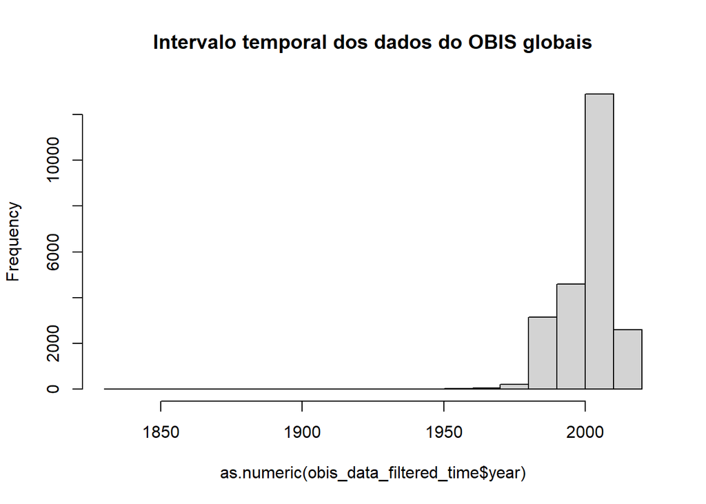

```r
# histogramas (convertendo as colunas para valor numérico)
hist(as.numeric(obis_data_filtered_time$year), main="Intervalo temporal dos dados do OBIS globais")
```

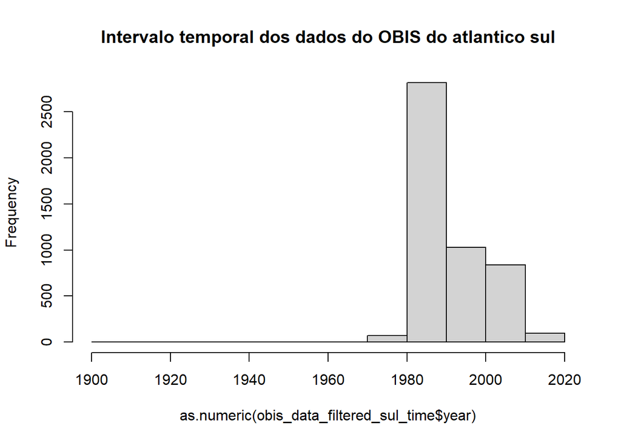

```r
hist(as.numeric(obis_data_filtered_sul_time$year), main="Intervalo temporal dos dados do OBIS do atlantico sul")
```

# GBIF

https://www.gbif.org/species/2374191

Para achar o link, basta entrar no GBIF, ir em Species, procurar por Katsuwonus Pelamis, clicar no 1° resultado -> Katsuwonus pelamis (Linnaeus, 1758)

Para fazer o download, é preciso clicar no botão verde “Occurrences”, ir para “Download”, clicar no botão verde “Simple”, e então esperar o download e finalmente clicar no botão verde “Download”

O .csv usado é o arquivo único encontrado dentro do zip que foi baixado

Notas: Usar o filtro de Occurence Status para “Present” para não usar dados de ausência, ou “Everything” para usar ambos de presença e ausência. O .csv utilizado neste exemplo possui somente os dados de presença do bonito-listrado

O GBIF usa, a princípio, de muitos do mesmos datasets do OBIS

### Exploração inicial

```r
# Carregando o arquivo
gbif_data <- read.csv("ocorrencias_katsuwonus/gbif/0030473-241007104925546.csv", sep='\t')
names(gbif_data)
```

```
##  [1] "gbifID"                           "datasetKey"
##  [3] "occurrenceID"                     "kingdom"
##  [5] "phylum"                           "class"
##  [7] "order"                            "family"
##  [9] "genus"                            "species"
## [11] "infraspecificEpithet"             "taxonRank"
## [13] "scientificName"                   "verbatimScientificName"
## [15] "verbatimScientificNameAuthorship" "countryCode"
## [17] "locality"                         "stateProvince"
## [19] "occurrenceStatus"                 "individualCount"
## [21] "publishingOrgKey"                 "decimalLatitude"
## [23] "decimalLongitude"                 "coordinateUncertaintyInMeters"
## [25] "coordinatePrecision"              "elevation"
## [27] "elevationAccuracy"                "depth"
## [29] "depthAccuracy"                    "eventDate"
## [31] "day"                              "month"
## [33] "year"                             "taxonKey"
## [35] "speciesKey"                       "basisOfRecord"
## [37] "institutionCode"                  "collectionCode"
## [39] "catalogNumber"                    "recordNumber"
## [41] "identifiedBy"                     "dateIdentified"
## [43] "license"                          "rightsHolder"
## [45] "recordedBy"                       "typeStatus"
## [47] "establishmentMeans"               "lastInterpreted"
## [49] "mediaType"                        "issue"
```

```r
# Verificando se têm ocorrências sem latitude ou longitude (neste caso, tem)
nrow(gbif_data) # 29915
```

```
## [1] 29915
```

```r
gbif_data_filtered <- gbif_data %>%
  drop_na(decimalLongitude, decimalLatitude)
nrow(gbif_data_filtered) # 28279
```

```
## [1] 28279
```

```r
# simplificando os nomes
gbif_data_filtered$lat = gbif_data_filtered$decimalLatitude
gbif_data_filtered$long = gbif_data_filtered$decimalLongitude
```

```r
# Formato dos dados espaciais
head(gbif_data_filtered$lat)
```

```
## [1]   0.000000  25.500000   3.578800  12.178400 -11.700000  -0.018333
```

```r
head(gbif_data_filtered$long)
```

```
## [1]    0.0000  -79.8333   72.9021  -68.2385   43.2500 -175.9283
```

As coordenadas de latitude e longitude são definidas como valores contínuos, com 4 casas decimais. Os valores que possuem mais casas são apenas arredondamentos, a princípio

### Extensão espacial dos dados

```r
# verificando se todos os dados estão incluídos nos intervalos de lat/lon globais
gbif_data_filtered_ext <- subset(gbif_data_filtered, lat >= lat_min & lat <= lat_max & long >= long_min & long <= long_max)
nrow(gbif_data_filtered_ext) # 28279 ->
```

```
## [1] 28279
```

```r
# mesmo número de linhas que os dados normais, ou seja, todos os dados estão nesses intervalos
```

```r
# agrupando os pontos de ocorrência em células
occ_raster_gbif <- terra::rasterize(
  data.matrix(gbif_data_filtered[, c('long', 'lat')]), # dados espaciais (colunas com x e y) em forma de matriz
  occ_raster, # objeto spatRaster criado anteriormente
  fun=length # função de agrupamento (irá contar quantos pontos existe naquela célula)
)

# paleta de cores definida para os valores do raster
pal <- colorNumeric(
  palette = palette_name,
  domain = values(occ_raster_gbif)
)

# visualizando o raster de ocorrências
leaflet() %>%
  addTiles() %>%  # Adiciona o mapa base
  addRasterImage(colors=palette_name, occ_raster_gbif, opacity = 0.75) %>%
  addLegend(pal = pal, values = values(occ_raster_gbif), title = "Densidade ocor. GBIF")
```

[interactive chart not shown]

```r
# filtrando apenas ocorrências do atlântico sul
gbif_data_filtered_sul <- subset(gbif_data_filtered, lat >= lat_min_sul & lat <= lat_max_sul & long >= long_min_sul & long <= long_max_sul)
nrow(gbif_data_filtered_sul) # 1757
```

```
## [1] 1757
```

### Extensão temporal dos dados

```r
# tabela de valores referentes ao ano
table(gbif_data_filtered$year, useNA="ifany")
```

```
##
## 1835 1845 1849 1856 1859 1860 1861 1872 1883 1886 1905 1921 1922 1925 1928 1929
##    1    1    1    1    1    1    2    3    1    1    1    2    2    2    1    1
## 1930 1932 1933 1937 1938 1941 1944 1945 1946 1951 1952 1953 1954 1955 1956 1957
##    4    2    3    1    1    2    1    1    1    1    3    6    4    2    4    9
## 1958 1959 1960 1961 1962 1963 1964 1965 1966 1967 1968 1969 1970 1971 1972 1973
##    4    1    4    4    2    7  218    8   20   23  109   43   35   10   62   22
## 1974 1975 1976 1977 1978 1979 1980 1981 1982 1983 1984 1985 1986 1987 1988 1989
##   13    5   22   94  151   44   25   34   29   31   61  132   18   26    9   54
## 1990 1991 1992 1993 1994 1995 1996 1997 1998 1999 2000 2001 2002 2003 2004 2005
##    2    1  264  230  261  226  185  219 1380 1033 1551 1167 1290 1141 1712 1476
## 2006 2007 2008 2009 2010 2011 2012 2013 2014 2015 2016 2017 2018 2019 2020 2021
## 2460 2680 2418  921 1548 1213 1369 1383   12   21  229  160   13   10   34   11
## 2022 2023 2024 <NA>
##   17   18   19  218
```

```r
# anos mínimos e máximos dos dados globais e somente do oceano atlantico sul
# precisamos usar na.rm = TRUE pois existem valores ausentes
paste(min(gbif_data_filtered$year, na.rm = TRUE), "-", max(gbif_data_filtered$year, na.rm = TRUE))
```

```
## [1] "1835 - 2024"
```

```r
paste(min(gbif_data_filtered_sul$year, na.rm = TRUE), "-", max(gbif_data_filtered_sul$year, na.rm = TRUE))
```

```
## [1] "1859 - 2024"
```

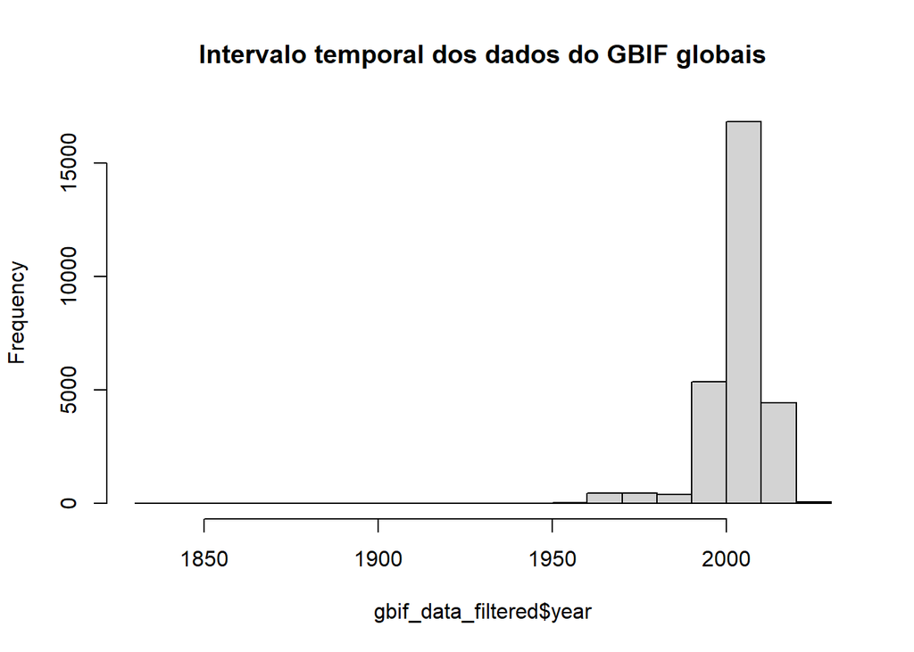

```r
# histogramas
hist(gbif_data_filtered$year, main="Intervalo temporal dos dados do GBIF globais")
```

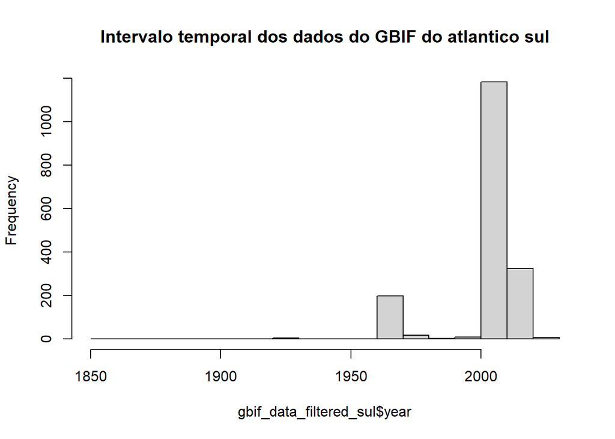

```r
hist(gbif_data_filtered_sul$year, main="Intervalo temporal dos dados do GBIF do atlantico sul")
```

# ICCAT

Datasets - https://www.iccat.int/en/accesingdb.html

Manual ICCAT - https://www.iccat.int/en/iccatmanual.html

Para achar o link, basta entrar no ICCAT, e ir para Statistics -> Access to ICCAT Statistics Databases

Os datasets que se referem à “Task 1” incluem dados de pesca agrupados por grandes regiões, identificados apenas pelo seu código (ver regiões abaixo). E os datasets que se referem à “Task 2” incluem dados de pesca identificados pelas coordenadas, com resolução corresponde ao “GeoStrata”, que podem ser 5x5 graus, 1x1 graus ou pontos lat/lon

[figure not shown]

Uma explicação mais detalhada existe tanto no manual geral, em “1.1 What is ICCAT?” como no glossário, disponível em https://www.iccat.int/Documents/SCRS/Manual/Appendices/Appendix%207%20glossary.zip

A task 1 não será utilizada nesta exploração.

Para os dados referentes à Task 2, o dataset usado pode ser encontrado a partir da página de datasets em “Sample fishing statistics and fish sizes” -> “Task 2 size” -> “T2SZ - size frequencies (observed)” -> “SKJ Skipjack tuna” . A sigla “SZ” se refere ao fato que as amostras biológicas do peixe foram medidas/pesadas, e não estimadas. Este dataset foi escolhido para análise inicial pois fornecerá as medições reais dos peixes e também terá a maior resolução espacial entre os datasets disponibilizados pelo iccat (outros parecem possuir resolução de 5x5 graus, apenas)

O .csv usado é o arquivo único encontrado dentro do zip que foi baixado

Explicação das variáveis do dataset disponível em https://www.iccat.int/Data/t2size/ReadmeT2SZ-CS.pdf

### Exploração inicial (Task 2)

```r
# Carregando o arquivo
iccat_data <- read.csv("ocorrencias_katsuwonus/iccat/t2sz_SKJ1950-22/t2sz_SKJ1950-22.csv")
names(iccat_data)
```

```
##  [1] "InProcID"        "SpeciesCode"     "YearC"           "Decade"
##  [5] "FlagName"        "FleetCode"       "GearGrpCode"     "GearCode"
##  [9] "LorD"            "FreqTypeCode"    "SzInterval"      "FreqsGroup"
## [13] "SizeInfoCode"    "FileTypeCode"    "StrataID"        "TimePeriodCatch"
## [17] "TimeStrata"      "SchoolTypeCode"  "Stock"           "SampAreaCode"
## [21] "GeoStrata"       "QuadID"          "Lat"             "Lon"
## [25] "FishSampWGT"     "FishSampNUM"     "ClassFrq"        "SexCode"
## [29] "Nr"
```

```r
# Verificando se têm ocorrências sem latitude ou longitude (neste caso, não)
nrow(iccat_data) # 786587
```

```
## [1] 786587
```

```r
iccat_data_filtered <- iccat_data %>%
  drop_na(Lon, Lat)
nrow(iccat_data_filtered) # 786587
```

```
## [1] 786587
```

```r
# Formato dos dados espaciais
head(iccat_data_filtered$Lat)
```

```
## [1] 0 0 0 0 0 0
```

```r
head(iccat_data_filtered$Lon)
```

```
## [1] 10 10 10 10 10 10
```

```r
min(iccat_data_filtered$Lon)
```

```
## [1] 0
```

```r
max(iccat_data_filtered$Lat)
```

```
## [1] 56
```

Todos os valores de lat/lon são absolutos, então precisaremos ajustar isso usando os quadrantes para plotar com o Leaflet

[figure not shown]

```r
# Se o quadrante é >= 3, a longitude deveria ser negativa
iccat_data_filtered$long <- ifelse(iccat_data_filtered$QuadID>=3, iccat_data_filtered$Lon*-1, iccat_data_filtered$Lon)

# Se o quadrante é >= 2 e <= 3, a latitude deveria ser negativa
iccat_data_filtered$lat <- ifelse(iccat_data_filtered$QuadID>=2 & iccat_data_filtered$QuadID<=3, iccat_data_filtered$Lat*-1, iccat_data_filtered$Lat)
```

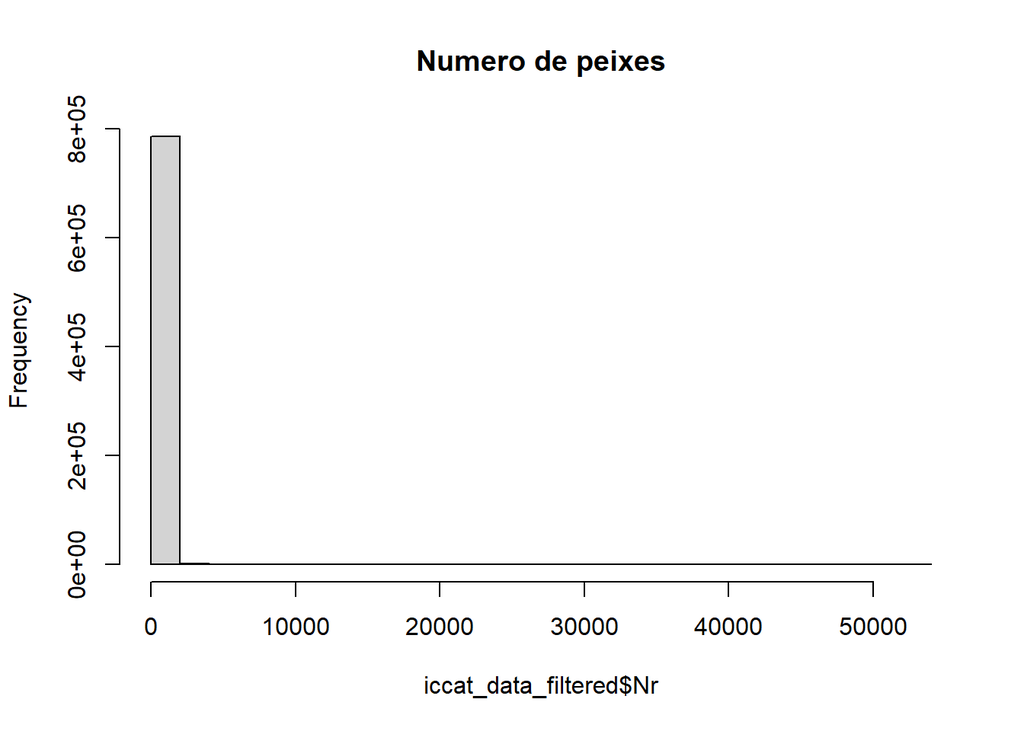

```r
# número de peixes (maioria tem valores bem baixos)
hist(iccat_data_filtered$Nr, main="Numero de peixes")
```

```r
# vendo quais são as diferentes resoluções
table(iccat_data_filtered$GeoStrata)
```

```
##
##  10x10  10x20    1x1   5x10    5x5  ICCAT LatLon
##   2063    104 717901   4709  41686  19900    224
```

explicação das diferentes resoluções: https://www.iccat.int/Forms/CODES_SquareTypes.xlsx

Pelo que entendi, a resolução “ICCAT” quer dizer que ele apenas irá identificar a área conforme o código da região

```r
# usando apenas os registros com resolução de 1x1 grau
iccat_data_filtered_1x1 <- iccat_data_filtered[iccat_data_filtered$GeoStrata == "1x1",]
nrow(iccat_data_filtered_1x1) # 717901
```

```
## [1] 717901
```

### Extensão espacial dos dados

```r
# verificando se todos os dados estão incluídos nos intervalos de lat/lon
iccat_data_filtered_1x1_ext <- subset(iccat_data_filtered_1x1, lat >= lat_min & lat <= lat_max & long >= long_min & long <= long_max)
nrow(iccat_data_filtered_1x1_ext) # 717901 ->
```

```
## [1] 717901
```

```r
# mesmo número de linhas que os dados normais, ou seja, todos os dados estão nesses intervalos
```

```r
# agrupando os pontos de ocorrência em células
occ_raster_iccat <- terra::rasterize(
  data.matrix(iccat_data_filtered_1x1[, c('long', 'lat')]), # dados espaciais (colunas com x e y) em forma de matriz
  occ_raster, # objeto spatRaster criado anteriormente
  fun=length # função de agrupamento (irá contar quantos pontos existe naquela célula)
)

# paleta de cores definida para os valores do raster
pal <- colorNumeric(
  palette = palette_name,
  domain = values(occ_raster_iccat)
)

# visualizando o raster de ocorrências
leaflet() %>%
  addTiles() %>%  # Adiciona o mapa base
  addRasterImage(colors=palette_name, occ_raster_iccat, opacity = 0.75) %>%
  addLegend(pal = pal, values = values(occ_raster_iccat), title = "Densidade ocor. ICCAT")
```

[interactive chart not shown]

```r
# filtrando apenas ocorrências do atlântico sul
iccat_data_filtered_1x1_sul <- subset(iccat_data_filtered_1x1, lat >= lat_min_sul & lat <= lat_max_sul & long >= long_min_sul & long <= long_max_sul)
nrow(iccat_data_filtered_1x1_sul) # 597570
```

```
## [1] 597570
```

### Extensão temporal dos dados

```r
# tabela de valores referentes ao ano (aqui não existem valores ausentes)
table(iccat_data_filtered_1x1$YearC, useNA="ifany")
```

```
##
##  1968  1969  1970  1971  1972  1973  1974  1975  1976  1977  1978  1979  1980
##    88  2010  2770  3833  4540  3142  4046  2514  2988  6008  5481  2005  8770
##  1981  1982  1983  1984  1985  1986  1987  1988  1989  1990  1991  1992  1993
##  7330  8110  8963  9391  8971  9362  8728 14192 10269  6262 10622  9658 11354
##  1994  1995  1996  1997  1998  1999  2000  2001  2002  2003  2004  2005  2006
## 13132 15228 12247 10647  6047  5342 10562 11249 12322 15451 15624 16012 17830
##  2007  2008  2009  2010  2011  2012  2013  2014  2015  2016  2017  2018  2019
## 14175 17288 21987 21188 24789 20731 26158 26312 25425 30668 31680 21306 35491
##  2020  2021  2022
## 18269 27925 21409
```

```r
# anos mínimos e máximos dos dados globais e somente do oceano atlantico sul
paste(min(iccat_data_filtered_1x1$YearC), "-", max(iccat_data_filtered_1x1$YearC))
```

```
## [1] "1968 - 2022"
```

```r
paste(min(iccat_data_filtered_1x1_sul$YearC), "-", max(iccat_data_filtered_1x1_sul$YearC))
```

```
## [1] "1968 - 2022"
```

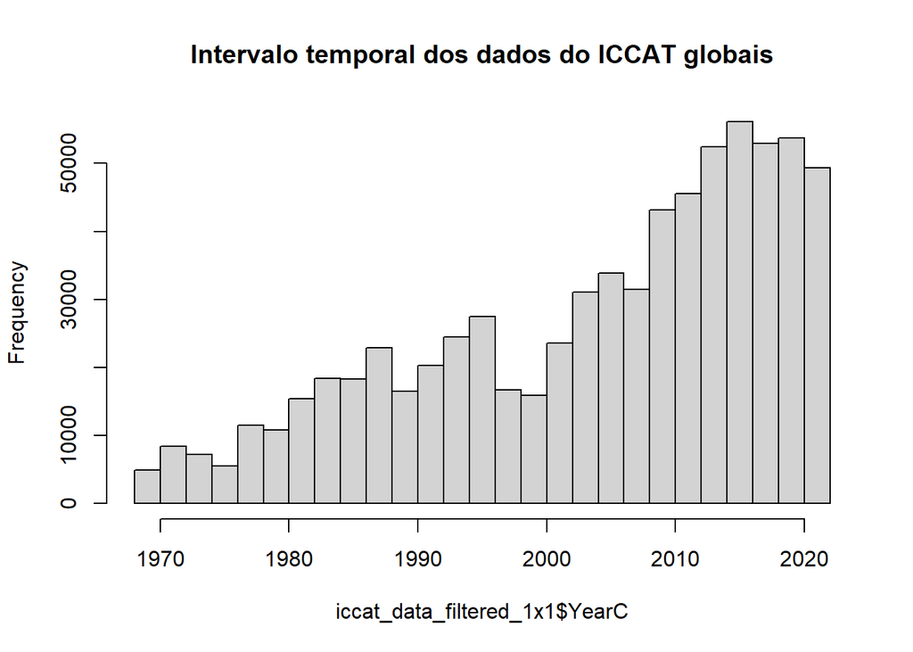

```r
# histogramas
hist(iccat_data_filtered_1x1$YearC, main="Intervalo temporal dos dados do ICCAT globais")
```

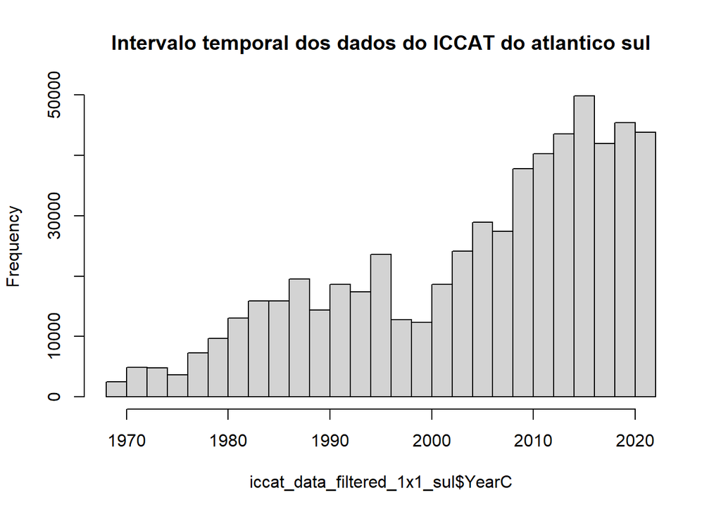

```r
hist(iccat_data_filtered_1x1_sul$YearC, main="Intervalo temporal dos dados do ICCAT do atlantico sul")
```